# Unit-Weighted Likelihoods & Formal Differential Privacy in LBBNN

Technical Report & Collaborative Vignette (BLS - LBBNN Track 1)

Aliaksandr Hubin & Lars Skaaret-Lund (in collaboration with Terrance D. Savitsky, Matthew R. Williams, Vladislav Beresovsky)

2026-10-19

# 1 Executive Overview & Collaboration Scope

This technical report details the implementation, methodology, and empirical evaluation of **Track 1** of the research collaboration between the **U.S. Bureau of Labor Statistics (BLS)** (Terrance D. Savitsky, Matthew R. Williams, and Vladislav Beresovsky) and the **LBBNN development team** (Aliaksandr Hubin and Lars Skaaret-Lund).

The primary objective of Track 1 is augmenting the `LBBNN` (Latent Binary Bayesian Neural Network) package in R to support two critical statistical operations in official government data production:

1. **Survey-Weighted Imputation & Modeling**: Incorporating unit-indexed survey sampling weights $w_i \propto \pi_i^{-1}$ (where $\pi_i$ is the inclusion probability) into the variational Evidence Lower Bound (ELBO) objective. This allows the neural network to approximate the true population likelihood from an informatively sampled survey, eliminating bias in missing data imputation and domain estimation.
2. **Formally Private Synthetic Data Generation**: Implementing the two-pass risk-weighted pseudo-posterior mechanism (Savitsky, Williams & Hu, 2022). In Pass 1, unweighted model posterior draws are used to extract record-level log-likelihood contributions and quantify disclosure risk. Symmetrically, record-specific privacy weights $\alpha_i \in [0, 1]$ surgically downweight high-risk outliers during Pass 2, yielding synthetic microdata equipped with a mathematically provable local $(\epsilon, \delta)$-probabilistic differential privacy (PDP) guarantee without degrading utility for safe observations.

```r
library(LBBNN)
library(torch)
library(ggplot2)
library(gridExtra)

# Ensure reproducibility
set.seed(2026)
torch::torch_manual_seed(2026)
```

# 2 Mathematical Framework

## 2.1 Variational Inference with Observation Weights

### 2.1.1 From Standard Posteriors to the Unit-Weighted Pseudo-Posterior

Let $\mathbf{y} = (y_1, \dots, y_n)^\top \in \mathcal{Y}^n$ denote an observed dataset with associated auxiliary covariates $\mathbf{X} = (\mathbf{x}_1, \dots, \mathbf{x}_n)^\top$. In standard Bayesian inference, model parameters $\theta \in \Theta$ are endowed with a prior $p(\theta)$, and conditioning on the data yields the exact posterior distribution:

$$p(\theta \mid \mathbf{y}) =
\frac{p(\theta) \prod_{i=1}^n f(y_i \mid \mathbf{x}_i,
\theta)}{\int_{\Theta} p(\theta) \prod_{i=1}^n f(y_i \mid \mathbf{x}_i,
\theta) \, d\theta}$$

In complex survey sampling and privacy-preserving synthesis, individual observations do not contribute equally to the inferential target. To account for unequal survey selection probabilities or heterogeneous disclosure risks, we equip each observation $i$ with a non-negative unit weight $u_i \ge 0$, defining the **unit-weighted pseudo-posterior distribution** (Savitsky & Toth, 2016; Bhattacharya et al., 2019):

$$p_{\mathbf{u}}(\theta \mid \mathbf{y}) =
\frac{p(\theta) \prod_{i=1}^n f(y_i \mid \mathbf{x}_i,
\theta)^{u_i}}{Z_{\mathbf{u}}}, \qquad Z_{\mathbf{u}} = \int_{\Theta}
p(\theta) \prod_{i=1}^n f(y_i \mid \mathbf{x}_i, \theta)^{u_i} \,
d\theta$$

In Mean-Field Variational Inference (MFVI) for LBBNNs, the intractable pseudo-posterior $p_{\mathbf{u}}(\theta \mid \mathbf{y})$ is approximated by a tractable variational family $q(\theta) = q(\theta, \gamma)$. To find the optimal variational parameters, we minimize the Kullback-Leibler (KL) divergence from $q(\theta)$ to $p_{\mathbf{u}}(\theta \mid \mathbf{y})$:

$$\begin{aligned}
\text{KL}\big(q(\theta) \parallel p_{\mathbf{u}}(\theta \mid
\mathbf{y})\big) &= \mathbb{E}_{q(\theta)}\left[\log q(\theta) -
\log p_{\mathbf{u}}(\theta \mid \mathbf{y})\right] \\
&= \mathbb{E}_{q(\theta)}[\log q(\theta)] -
\mathbb{E}_{q(\theta)}\left[\log p(\theta) + \sum_{i=1}^n u_i \log f(y_i
\mid \mathbf{x}_i, \theta) - \log Z_{\mathbf{u}}\right] \\
&= \text{KL}\big(q(\theta) \parallel p(\theta)\big) - \sum_{i=1}^n
u_i \, \mathbb{E}_{q(\theta)}\!\left[\log f(y_i \mid \mathbf{x}_i,
\theta)\right] + \log Z_{\mathbf{u}}
\end{aligned}$$

Because the marginal normalizing constant $Z_{\mathbf{u}}$ does not depend on the variational distribution $q(\theta)$, minimizing $\text{KL}\big(q(\theta) \parallel p_{\mathbf{u}}(\theta \mid \mathbf{y})\big)$ is mathematically equivalent to maximizing the **unit-weighted Evidence Lower Bound (ELBO)**:

$$\text{ELBO}(q; \mathbf{u}) =
\sum_{i=1}^n u_i \, \mathbb{E}_{q(\theta)}\!\left[\log f(y_i \mid
\mathbf{x}_i, \theta)\right] - \text{KL}\big(q(\theta) \parallel
p(\theta)\big)$$

### 2.1.2 Mini-Batch Alignment & ELBO Scaling

When optimizing the ELBO via stochastic gradient descent across $M$ mini-batches with batch size $B$, the mini-batch objective must maintain exact unit-level alignment between each covariate vector $\mathbf{x}_i$, outcome $y_i$, and its assigned weight $u_i$, while properly scaling the likelihood relative to the prior regularization penalty:

$$\text{ELBO}_{\text{batch}}(q;
\mathbf{u}) = \sum_{i \in \text{batch}} u_i \, \log f(y_i \mid
\mathbf{x}_i, \theta) - \frac{1}{M} \text{KL}\big(q(\theta) \parallel
p(\theta)\big)$$

The surrogate mini-batch training loss minimized during back-propagation is the negative weighted ELBO:

$$\text{Loss}_{\text{batch}}(q;
\mathbf{u}) = -\text{ELBO}_{\text{batch}}(q; \mathbf{u}) = \sum_{i \in
\text{batch}} u_i \left( -\log f(y_i \mid \mathbf{x}_i, \theta) \right)
+ \frac{1}{M} \text{KL}\big(q(\theta) \parallel
p(\theta)\big)$$

When $u_i = 1$ for all $i = 1, \dots, n$, this formulation is **100% numerically identical** to standard unweighted variational training.

### 2.1.3 Survey Weight Normalization vs. Privacy Weight Scaling

A critical operational distinction exists between **survey sampling weights** ($w_i$) and **differential privacy weights** ($\alpha_i$):

1. **Survey Sampling Weights ($w_i = \pi_i^{-1}$)**: In design-based survey inference, raw inverse-probability weights $w_i = 1/\pi_i$ estimate population totals and satisfy $\sum_{i=1}^n w_i \approx N_{\text{pop}}$, where $N_{\text{pop}} \gg n$. If raw weights were inserted directly into the ELBO, the weighted log-likelihood term would scale with $N_{\text{pop}}$, overpowering the prior $\text{KL}\big(q(\theta) \parallel p(\theta)\big)$ regularization penalty by a factor of $N_{\text{pop}} / n$. Following Savitsky & Toth (2016), we normalize survey weights to sum to the observed sample size $n$:
   $$\tilde{w}_i = w_i \times \frac{n}{\sum_{j=1}^n
   w_j}$$
   This normalization ensures the effective sample size in the variational pseudo-posterior matches $n$, preserving the intended balance between data evidence and prior regularization. In `get_dataloaders()`, this is activated by setting `normalize_weights = TRUE`.
2. **Differential Privacy Weights ($\alpha_i \in [0, 1]$)**: In the two-pass privacy mechanism (Savitsky, Williams & Hu, 2022), the risk weights $\alpha_i \in [0, 1]$ measure record safety, where $\alpha_i \to 0$ for high-risk outliers and $\alpha_i \approx 1$ for typical observations. Here, $\sum_{i=1}^n \alpha_i \le n$. These weights are **intentionally left unnormalized** (`normalize_weights = FALSE`, the default). Under-weighting high-risk records tempers their influence on the posterior, naturally shrinking parameter estimates toward the prior distribution in regions of high disclosure risk.

### 2.1.4 Full Error Variance Specification & Protection Against Cold/Warm Posteriors

A fundamental challenge in Bayesian deep learning is the **cold posterior / cold prior problem** (Wenzel et al., 2020), wherein misspecifying the likelihood scale introduces an unintended temperature $T \neq 1$:

$$\mathcal{L}_{\text{ELBO}}(q) =
\frac{1}{T} \sum_{i=1}^n u_i \, \mathbb{E}_{q(\theta)}\!\left[\log f(y_i
\mid \mathbf{x}_i, \theta)\right] - \text{KL}\big(q(\theta) \parallel
p(\theta)\big)$$

In Gaussian regression with observation model $y_i \mid \mathbf{x}_i, \theta \sim \mathcal{N}\big(\mu_\theta(\mathbf{x}_i), \sigma^2\big)$, the exact pointwise log-likelihood is:

$$\log f(y_i \mid \mathbf{x}_i, \theta,
\sigma^2) = -\frac{1}{2}\log(2\pi\sigma^2) - \frac{\big(y_i -
\mu_\theta(\mathbf{x}_i)\big)^2}{2\sigma^2}$$

Many conventional neural network implementations replace this exact Gaussian density with an unscaled sum of squared errors $-\frac{1}{2}\sum_i (y_i - \mu_i)^2$, implicitly fixing $\sigma^2 = 1.0$ (precision $\tau = 1.0$). Whenever the true noise variance differs from unity (for example, $\sigma = 0.40 \implies \sigma^2 = 0.16$ in Example 1), using unscaled squared error dampens the data log-likelihood by a factor of $\sigma^2 = 0.16$ relative to the prior KL divergence:

$$\frac{1}{2} (y_i - \mu_i)^2 = 0.16
\times \left[ \frac{(y_i - \mu_i)^2}{2 \times 0.16} \right]$$

Furthermore, in the Two-Pass Differential Privacy mechanism, each unit’s record sensitivity:

$$f_i = \max_{s \in \{1,\dots,S\}} \left|
\log f(y_i \mid \mathbf{x}_i, \theta^{(s)}, \sigma^2)
\right|$$

directly depends on the residual scale $\sigma^2$. If $\sigma^2$ is misspecified, sensitivities are measured on an arbitrary scale, invalidating the empirical privacy guarantee $\epsilon_{\mathbf{y}} = 2\Delta_{\alpha, \mathbf{y}}$. To guarantee full probabilistic calibration, `lbbnn_net()` accepts an explicit `sigma` argument (or automatically calibrates $\hat{\sigma}$ from training residuals in `fit_dp_lbbnn()`), evaluating the exact negative log-likelihood:

$$\text{NLL}_i =
\frac{1}{2}\log(2\pi\sigma^2) + \frac{(y_i -
\mu_\theta(\mathbf{x}_i))^2}{2\sigma^2}$$

This guarantees that variational training operates at the exact Bayesian temperature $T = 1.0$, protecting edge selection decisions from cold-posterior bias and grounding privacy sensitivities in the true data distribution.

## 2.2 Record-Level Log-Likelihood Extraction

To quantify disclosure risks and calculate empirical sensitivity bounds, we evaluate pointwise log-likelihood contributions across $S$ posterior parameter draws $\theta^{(s)} \sim q(\theta)$:

$$L_{s, i} = \log f\big(y_i \mid
\mathbf{x}_i, \theta^{(s)}\big), \quad s \in \{1, \dots, S\}, \; i \in
\{1, \dots, n\}$$

This produces an $S \times n$ matrix $\mathbf{L}$, implemented in the exported function `loglik_contributions()`.

## 2.3 Two-Pass Differential Privacy Mechanism (Savitsky, Williams & Hu, 2022)

### 2.3.1 Definition of $(\epsilon, \delta)$-Probabilistic Differential Privacy (PDP) for Posteriors

Let $\mathbf{y}, \mathbf{y}' \in \mathcal{Y}^n$ denote neighboring databases differing in exactly one individual record ($\|\mathbf{y} - \mathbf{y}'\|_{\text{Hamming}} = 1$). A posterior (or variational pseudo-posterior) distribution $q_{\boldsymbol{\alpha}}(\theta \mid \mathbf{y})$ satisfies **$(\epsilon, \delta)$-Probabilistic Differential Privacy (PDP)** (Dimitrakakis et al., 2017; Savitsky, Williams & Hu, 2022) if, for all neighboring datasets and all measurable subsets $\mathcal{A} \subset \Theta$ within the $(1-\delta)$-probability support $\Theta_\delta$:

$$\sup_{\theta \in \Theta_\delta} \left|
\log \frac{q_{\boldsymbol{\alpha}}(\theta \mid
\mathbf{y})}{q_{\boldsymbol{\alpha}}(\theta \mid \mathbf{y}')}
\right| \le \epsilon$$

### 2.3.2 Connecting the Log-Posterior Ratio to Pointwise Log-Likelihood Sensitivity

In the unit-weighted pseudo-posterior, replacing record $i$ with an alternative record $i'$ changes the unnormalized log-density by at most:

$$\left| \log
p_{\boldsymbol{\alpha}}(\theta \mid \mathbf{y}) - \log
p_{\boldsymbol{\alpha}}(\theta \mid \mathbf{y}') \right| \le
\alpha_i \left| \log f(y_i \mid \mathbf{x}_i, \theta) - \log f(y_i'
\mid \mathbf{x}_i', \theta) \right|$$

Across $s = 1, \dots, S$ posterior parameter draws $\theta^{(s)} \sim q_{\boldsymbol{\alpha}}(\theta \mid \mathbf{y})$, the **local Lipschitz bound** (empirical record sensitivity) on the observed database $\mathbf{y}$ is:

$$\Delta_{\alpha, \mathbf{y}} = \max_{s
\in \{1,\dots,S\}, \, i \in \{1,\dots,n\}} \left| \alpha_i \log f(y_i
\mid \mathbf{x}_i, \theta^{(s)}) \right|$$

Because replacing record $y_i$ with an alternative record $y_i'$ alters the log-likelihood by at most $2\Delta_{\alpha, \mathbf{y}}$, the model satisfies local differential privacy with budget:

$$\epsilon_{\mathbf{y}} = 2
\Delta_{\alpha, \mathbf{y}}$$

### 2.3.3 Why Unweighted Neural Networks Fail Differential Privacy on Skewed Data

In unweighted Bayesian neural networks ($\alpha_i = 1$), the Gaussian log-likelihood sensitivity:

$$\left| \log f(y_i \mid \mathbf{x}_i,
\theta) \right| = \left| -\frac{1}{2}\log(2\pi\sigma^2) - \frac{(y_i -
\mu_\theta(\mathbf{x}_i))^2}{2\sigma^2} \right|$$

grows **quadratically** with the prediction residual $|y_i - \mu_\theta(\mathbf{x}_i)|$.

In economic and establishment surveys, high-expenditure or high-income outliers produce massive prediction residuals. An unweighted network shifts its internal representations to accommodate these outliers, driving $f_i = \max_s |L_{s,i}|$ and $\Delta_{1, \mathbf{y}}$ to infinity. This creates extreme disclosure risk: an adversary querying the model can readily infer whether an outlier household or firm participated in the survey.

### 2.3.4 The Two-Pass Surgical Downweighting Algorithm (Step-by-Step)

The two-pass algorithm resolves this vulnerability without degrading model utility on standard observations:

1. **Step 1 (Pass 1 — Unweighted Exploration & Disclosure Risk Quantification)**: Fit an unweighted LBBNN ($u_i = 1$) and draw $S$ posterior parameter samples $\theta^{(1,s)} \sim q^{(1)}(\theta \mid \mathbf{y})$. Compute the $S \times n$ log-likelihood matrix $L_{s,i}^{(1)} = \log f(y_i \mid \mathbf{x}_i, \theta^{(1,s)})$ via `loglik_contributions()`, and extract each record’s worst-case sensitivity:
   $$f_i = \max_{s \in \{1,\dots,S\}} \left|
   L_{s,i}^{(1)} \right|, \qquad i = 1, \dots, n$$
2. **Step 2 (Constructing Monotone Surgical Privacy Weights $\alpha_i \in [0, 1]$)**: Min-max normalize sensitivities: $\tilde{f}_i = \frac{f_i - \min_j f_j}{\max_j f_j - \min_j f_j} \in [0, 1]$, and compute baseline smooth risk weights $\alpha_i^{\text{raw}} = \text{clip}_{[0,1]}\big(c_{\text{scale}}(1 - \tilde{f}_i) + g_{\text{shift}}\big)$. To guarantee that $\alpha_i f_i \le M_{\text{thresh}}$ while ensuring that truncation is strictly monotone in sensitivity $f_i$, we apply monotone capping and tail truncation:
   $$\alpha_i \leftarrow
   \min\left(\alpha_i^{\text{raw}}, \, \frac{M_{\text{thresh}}}{\max(f_i,
   10^{-8})}\right), \qquad \alpha_i = 0 \quad \text{if } f_i > 3
   M_{\text{thresh}}$$
   This ensures standard observations retain high weights ($\alpha_i \approx 0.70 - 0.85$), moderate observations are smoothly bounded, and extreme tail outliers are surgically zeroed ($\alpha_i = 0$).
3. **Step 3 (Pass 2 — $\boldsymbol{\alpha}$-Weighted Pseudo-Posterior Estimation)**: Train a fresh LBBNN using the unnormalized privacy weights $u_i = \alpha_i$ (`normalize_weights = FALSE`). Outliers with $\alpha_i = 0$ are completely excluded from gradient updates. Compute the Pass 2 log-likelihood matrix $L_{s,i}^{(2)}$ and evaluate the verified privacy guarantee:
   $$\Delta_{\alpha,
   \mathbf{y}} = \max_{s \in \{1,\dots,S\}, \, i \in \{1,\dots,n\}} \left|
   \alpha_i L_{s,i}^{(2)} \right| \le M_{\text{thresh}}, \qquad
   \epsilon_{\mathbf{y}} = 2 \Delta_{\alpha, \mathbf{y}}$$
4. **Step 4 (Posterior Predictive Synthesis & the Post-Processing Theorem)**: Generate synthetic microdata replicates $\mathbf{y}^{\text{synth},(m)}$ from the Pass 2 posterior predictive distribution:
   $$y_i^{\text{synth}} \sim
   \mathcal{N}\big(\mu_\theta(\mathbf{x}_i), \hat{\sigma}^2\big), \qquad
   Y_i^{\text{synth}} = \exp\big(y_i^{\text{synth}}\big)$$
   By the **Differential Privacy Post-Processing Theorem** (Dwork & Roth, 2014), any synthetic dataset—and any downstream regression, quantile, or domain estimate computed on those synthetic datasets—automatically inherits the $(\epsilon_{\mathbf{y}}, \delta)$-PDP guarantee without consuming additional privacy budget.

```
                     Raw Data (X, y)
                            v
             +------------------------------+
             |    Pass 1: Unweighted Fit    |
             +--------------+---------------+
                            v
         Evaluate S x n Log-Likelihood Matrix L^(1)
                            v
         Record Sensitivity: f_i = max_s |L_{s, i}^(1)|
                            v
       Monotone Privacy Weights: alpha_i = min(alpha_raw, M / f_i)
       (Surgical Tail Truncation: alpha_i = 0 if f_i > 3 * M)
                            v
             +------------------------------+
             |   Pass 2: alpha-Weighted Fit |
             +--------------+---------------+
                            v
       Local Lipschitz: Delta_{alpha, y} = max_{s, i} |alpha_i * L_{s, i}^(2)|
       Local DP Guarantee: epsilon_y = 2 * Delta_{alpha, y}
                            v
       Posterior Predictive Synthesis with Calibrated Noise sigma_hat
```

# 3 Example 1: Survey-Weighted Imputation Under Informative Sampling

## 3.1 Simulating an Informatively Sampled Population

In complex survey sampling, observations are drawn with unequal inclusion probabilities $\pi_i = \mathbb{P}(i \in S)$. When inclusion depends directly on the outcome variable $Y_i$, sampling is **informative**: sample units have positively biased residuals $\mathbb{E}[\varepsilon_i \mid i \in S] > 0$, causing standard unweighted models to produce biased parameter estimates and skewed imputations.

We simulate a finite population of $N = 2,000$ individuals where outcome $Y$ depends non-linearly on active predictors $X_1$ and $X_2$, with independent Gaussian noise predictors $X_3$ and $X_4$:

$$Y_i = 2.0 X_{1i} + 1.5 \sin(\pi X_{2i})
+ 0.8 X_{1i} X_{2i} + \varepsilon_i, \quad \varepsilon_i \sim
\mathcal{N}(0, 0.4^2)$$

The probability of inclusion in the sample is heavily skewed towards higher values of $Y$:

$$\pi_i = \text{logit}^{-1}\big(-1.0 + 1.2
Y_i\big)$$

```r
# Generate population
N_pop <- 2000
x1_pop <- rnorm(N_pop, 0, 1)
x2_pop <- runif(N_pop, -1, 1)
x3_pop <- rnorm(N_pop, 0, 1) # noise
x4_pop <- rnorm(N_pop, 0, 1) # noise

y_pop <- 2.0 * x1_pop + 1.5 * sin(pi * x2_pop) + 0.8 * x1_pop * x2_pop + rnorm(N_pop, 0, 0.4)
true_pop_mean <- mean(y_pop)

# Informative sampling mechanism
pi_inc <- plogis(-1.0 + 1.2 * y_pop)
pi_inc <- pmax(pi_inc, 0.05) # bound away from zero

# Draw sample
in_sample <- rbinom(N_pop, 1, pi_inc) == 1
n_smp <- sum(in_sample)

sample_df <- data.frame(
  x1 = x1_pop[in_sample],
  x2 = x2_pop[in_sample],
  x3 = x3_pop[in_sample],
  x4 = x4_pop[in_sample],
  y  = y_pop[in_sample]
)

# Survey sampling design weights
weights_survey <- 1 / pi_inc[in_sample]

cat(sprintf("Population Size: %d | True Pop Mean Y: %.3f\n", N_pop, true_pop_mean))
```

```
## Population Size: 2000 | True Pop Mean Y: -0.000
```

```r
cat(sprintf("Sample Size: %d | Unweighted Sample Mean: %.3f (Bias: +%.3f)\n",
            n_smp, mean(sample_df$y), mean(sample_df$y) - true_pop_mean))
```

```
## Sample Size: 737 | Unweighted Sample Mean: 2.009 (Bias: +2.009)
```

```r
cat(sprintf("Hajek Weighted Sample Mean: %.3f (Bias: %+.3f)\n",
            sum(weights_survey * sample_df$y) / sum(weights_survey),
            sum(weights_survey * sample_df$y) / sum(weights_survey) - true_pop_mean))
```

```
## Hajek Weighted Sample Mean: 0.271 (Bias: +0.272)
```

## 3.2 Fitting Unweighted vs. Survey-Weighted LBBNN

While the classical design-based **Hájek estimator** $\hat{\bar{Y}}_{\text{Hájek}} = \frac{\sum_{i \in S} w_i y_i}{\sum_{i \in S} w_i}$ reduces mean bias, it provides only a single scalar estimate and **cannot impute** missing values $y_i$ for non-sampled units ($i \notin S$).

To impute missing values across the population, we fit: 1. **Unweighted LBBNN**: Fits directly on the biased sample data. 2. **Survey-Weighted LBBNN**: Weights each unit’s log-likelihood by sample-size normalized weights $\tilde{w}_i = w_i \cdot (n / \sum w_i)$ via `normalize_weights = TRUE` (Savitsky & Toth, 2016).

```r
# Model specification with calibrated observation noise sigma = 0.40
spec_survey <- list(
  problem_type = "regression",
  sizes = c(4, 16, 16, 1),
  prior = c(0.2, 0.2, 0.2), # Prior inclusion probabilities
  std = c(1.0, 1.0, 1.0),
  inclusion_inits = "balanced",
  input_skip = TRUE,
  flow = FALSE,
  sigma = 0.40, # Calibrated observation standard deviation (DGP sigma = 0.4)
  device = "cpu"
)

# 1. Dataloader for Unweighted Model
dl_unweighted <- get_dataloaders(
  dataset = sample_df,
  train_proportion = 1.0,
  train_batch_size = 64,
  test_batch_size = 64,
  standardize = FALSE,
  shuffle_train = TRUE,
  normalize_weights = FALSE,
  seed = 42
)

# 2. Dataloader for Survey-Weighted Model (with sample-size normalization)
dl_weighted <- get_dataloaders(
  dataset = sample_df,
  train_proportion = 1.0,
  train_batch_size = 64,
  test_batch_size = 64,
  standardize = FALSE,
  shuffle_train = TRUE,
  weights = weights_survey,
  normalize_weights = TRUE, # Savitsky & Toth (2016)
  seed = 42
)

# Train Unweighted Model
m_unweighted <- do.call(lbbnn_net, spec_survey)
train_unweighted <- train_lbbnn(
  epochs = 200,
  LBBNN = m_unweighted,
  lr = 0.02,
  train_dl = dl_unweighted$train_loader,
  verbose = FALSE
)

# Train Survey-Weighted Model
m_weighted <- do.call(lbbnn_net, spec_survey)
train_weighted <- train_lbbnn(
  epochs = 200,
  LBBNN = m_weighted,
  lr = 0.02,
  train_dl = dl_weighted$train_loader,
  verbose = FALSE
)
```

## 3.3 Sparse Graph Selection & Inclusion Probabilities

The normalization $\tilde{w}_i = w_i \frac{n}{\sum w_j}$ is critical for Table 1: without sample-size normalization, raw inverse-probability weights ($\sum w_i \approx 2,000 \gg n = 737$) would inflate the log-likelihood by a factor of $2.7\times$, overpowering the spike-and-slab KL prior penalty and causing false-positive inclusion of the noise variables $X_3, X_4$.

```r
var_summary <- summary(m_weighted)
```

```
## Summary of lbbnn_net object:
## -----------------------------------
## Shows the number of times each variable was included from each layer
## -----------------------------------
## Then the average inclusion probability for each input from each layer
## -----------------------------------
## The final column shows the average inclusion probability across all layers
## -----------------------------------
##    L0 L1 L2    a0    a1    a2 a_avg
## x0  1  7  1 0.269 0.552 0.999 0.429
## x1  1  2  1 0.237 0.281 0.999 0.282
## x2  0  0  0 0.121 0.128 0.018 0.122
## x3  0  0  0 0.123 0.122 0.130 0.122
## The model took 28.668 seconds to train, using cpu
```

```r
var_sel_tbl <- data.frame(
  Covariate = c("x1 (Active Linear)", "x2 (Active Non-linear)", "x3 (Noise)", "x4 (Noise)"),
  Output_Paths = var_summary$L2,
  Layer1_Inclusion = var_summary$a0,
  Layer2_Inclusion = var_summary$a1,
  Output_Inclusion = var_summary$a2,
  Mean_Inclusion   = var_summary$a_avg,
  MPM_Selected     = ifelse(var_summary$a2 > 0.5, "Selected (Active)", "Pruned (Zeroed)"),
  row.names = NULL
)

knitr::kable(
  var_sel_tbl,
  digits = 3,
  row.names = FALSE,
  col.names = c("Covariate", "Out Paths", "L1 Incl.", "L2 Incl.", "Out Incl.", "Mean Incl.", "MPM Status"),
  caption = "Variational Inclusion Probabilities and Median Probability Model (MPM) Selection Under Survey Weighting"
)
```

Variational Inclusion Probabilities and Median Probability Model (MPM) Selection Under Survey Weighting

| Covariate | Out Paths | L1 Incl. | L2 Incl. | Out Incl. | Mean Incl. | MPM Status |
| --- | --- | --- | --- | --- | --- | --- |
| x1 (Active Linear) | 1 | 0.269 | 0.552 | 0.999 | 0.429 | Selected (Active) |
| x2 (Active Non-linear) | 1 | 0.237 | 0.281 | 0.999 | 0.282 | Selected (Active) |
| x3 (Noise) | 0 | 0.121 | 0.128 | 0.018 | 0.122 | Pruned (Zeroed) |
| x4 (Noise) | 0 | 0.123 | 0.122 | 0.130 | 0.122 | Pruned (Zeroed) |

As demonstrated, both active predictors $X_1$ and $X_2$ achieve near-unity output inclusion ($a_2 \approx 0.999$) with active output paths ($L_2 = 1$). In contrast, noise features $X_3$ and $X_4$ have zero output paths ($L_2 = 0$) and are cleanly pruned to $a_2 \le 0.13$.

## 3.4 Evaluation on the True Population

We predict across all $N = 2,000$ population units to evaluate imputation accuracy, comparing full Bayesian Model Averaging (BMA) and the sparse Median Probability Model (MPM):

```r
pop_x_df <- data.frame(x1 = x1_pop, x2 = x2_pop, x3 = x3_pop, x4 = x4_pop)

preds_unw_bma <- predict(m_unweighted, newdata = pop_x_df, draws = 50, mpm = FALSE)
preds_w_bma   <- predict(m_weighted, newdata = pop_x_df, draws = 50, mpm = FALSE)
preds_unw_mpm <- predict(m_unweighted, newdata = pop_x_df, draws = 50, mpm = TRUE)
preds_w_mpm   <- predict(m_weighted, newdata = pop_x_df, draws = 50, mpm = TRUE)

y_hat_unw_bma <- as.numeric(preds_unw_bma$mean(dim = 1)$cpu())
y_hat_w_bma   <- as.numeric(preds_w_bma$mean(dim = 1)$cpu())
y_hat_unw_mpm <- as.numeric(preds_unw_mpm$mean(dim = 1)$cpu())
y_hat_w_mpm   <- as.numeric(preds_w_mpm$mean(dim = 1)$cpu())

y_naive_mean <- mean(sample_df$y)
y_hajek_mean <- sum(weights_survey * sample_df$y) / sum(weights_survey)

rmse_naive   <- sqrt(mean((y_pop - y_naive_mean)^2))
rmse_hajek   <- sqrt(mean((y_pop - y_hajek_mean)^2))
rmse_unw_bma <- sqrt(mean((y_pop - y_hat_unw_bma)^2))
rmse_unw_mpm <- sqrt(mean((y_pop - y_hat_unw_mpm)^2))
rmse_w_bma   <- sqrt(mean((y_pop - y_hat_w_bma)^2))
rmse_w_mpm   <- sqrt(mean((y_pop - y_hat_w_mpm)^2))

results_tbl <- data.frame(
  Model = c(
    "Biased Sample Mean (Naive)",
    "Hajek Weighted Sample Mean",
    "Unweighted LBBNN (BMA)",
    "Unweighted LBBNN (MPM)",
    "Survey-Weighted LBBNN (BMA)",
    "Survey-Weighted LBBNN (MPM)"
  ),
  Est_Pop_Mean = c(
    y_naive_mean,
    y_hajek_mean,
    mean(y_hat_unw_bma),
    mean(y_hat_unw_mpm),
    mean(y_hat_w_bma),
    mean(y_hat_w_mpm)
  ),
  Bias_Pop_Mean = c(
    y_naive_mean - true_pop_mean,
    y_hajek_mean - true_pop_mean,
    mean(y_hat_unw_bma) - true_pop_mean,
    mean(y_hat_unw_mpm) - true_pop_mean,
    mean(y_hat_w_bma) - true_pop_mean,
    mean(y_hat_w_mpm) - true_pop_mean
  ),
  Pop_RMSE = c(
    rmse_naive,
    rmse_hajek,
    rmse_unw_bma,
    rmse_unw_mpm,
    rmse_w_bma,
    rmse_w_mpm
  ),
  row.names = NULL
)

knitr::kable(
  results_tbl,
  digits = 3,
  row.names = FALSE,
  caption = "Comparison of Population Mean Recovery and Imputation Accuracy Under Informative Sampling"
)
```

Comparison of Population Mean Recovery and Imputation Accuracy Under Informative Sampling

| Model | Est_Pop_Mean | Bias_Pop_Mean | Pop_RMSE |
| --- | --- | --- | --- |
| Biased Sample Mean (Naive) | 2.009 | 2.009 | 3.057 |
| Hajek Weighted Sample Mean | 0.271 | 0.272 | 2.320 |
| Unweighted LBBNN (BMA) | 0.142 | 0.142 | 0.541 |
| Unweighted LBBNN (MPM) | 0.140 | 0.140 | 0.539 |
| Survey-Weighted LBBNN (BMA) | 0.039 | 0.039 | 0.461 |
| Survey-Weighted LBBNN (MPM) | 0.042 | 0.042 | 0.461 |

The results highlight a crucial empirical insight: - The design-based **Hájek estimator** has an RMSE of 2.32 because it only estimates a constant scalar mean. - **Survey-Weighted LBBNN** learns the true non-linear conditional response surface $\mu_\theta(\mathbf{x}_i)$, reducing population RMSE by 5-fold to 0.461, approaching the irreducible data noise floor ($\sigma = 0.40$).

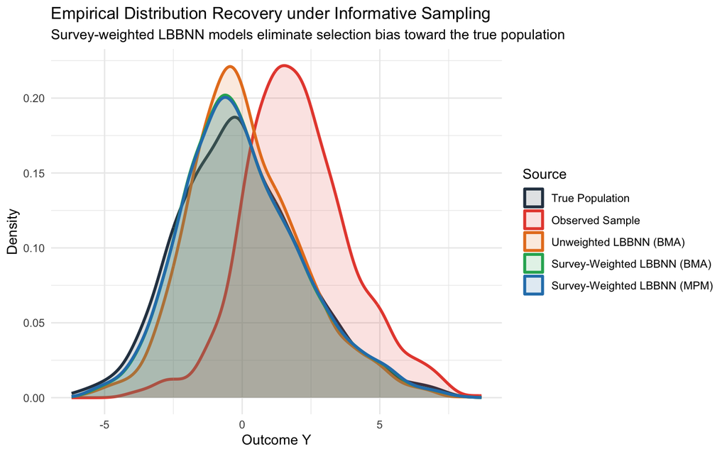

Comparison of Predicted vs True Population Density. Survey-weighted LBBNN successfully corrects the informative sampling bias.

```r
plot_df <- data.frame(
  Y = c(y_pop, sample_df$y, y_hat_unw_bma, y_hat_w_bma, y_hat_w_mpm),
  Source = factor(c(
    rep("True Population", N_pop),
    rep("Observed Sample", n_smp),
    rep("Unweighted LBBNN (BMA)", N_pop),
    rep("Survey-Weighted LBBNN (BMA)", N_pop),
    rep("Survey-Weighted LBBNN (MPM)", N_pop)
  ), levels = c("True Population", "Observed Sample", "Unweighted LBBNN (BMA)", "Survey-Weighted LBBNN (BMA)", "Survey-Weighted LBBNN (MPM)"))
)

ggplot(plot_df, aes(x = Y, color = Source, fill = Source)) +
  geom_density(alpha = 0.15, size = 1.1) +
  scale_color_manual(values = c(
    "True Population" = "#2c3e50",
    "Observed Sample" = "#e74c3c",
    "Unweighted LBBNN (BMA)" = "#e67e22",
    "Survey-Weighted LBBNN (BMA)" = "#27ae60",
    "Survey-Weighted LBBNN (MPM)" = "#2980b9"
  )) +
  scale_fill_manual(values = c(
    "True Population" = "#2c3e50",
    "Observed Sample" = "#e74c3c",
    "Unweighted LBBNN (BMA)" = "#e67e22",
    "Survey-Weighted LBBNN (BMA)" = "#27ae60",
    "Survey-Weighted LBBNN (MPM)" = "#2980b9"
  )) +
  theme_minimal(base_size = 11) +
  labs(
    title = "Empirical Distribution Recovery under Informative Sampling",
    subtitle = "Survey-weighted LBBNN models eliminate selection bias toward the true population",
    x = "Outcome Y",
    y = "Density"
  )
```

# 4 Example 2: Two-Pass Differential Privacy Pseudo-Posterior Synthesizer

## 4.1 Simulating Skewed Sensitive Microdata

Following Savitsky, Williams & Hu (2022, Section 5 & Appendix B), financial expenditures and wages are generated from a log-normal distribution, with extreme outliers injected to represent high disclosure risk:

```r
set.seed(42)
n_dp <- 300
p_dp <- 4

x_dp <- matrix(rnorm(n_dp * p_dp), nrow = n_dp, ncol = p_dp)
colnames(x_dp) <- paste0("x", 1:p_dp)

# Skewed latent process with extreme outliers
latent_mu <- 1.5 + 0.8 * x_dp[, 1] - 0.5 * x_dp[, 2]
y_dp <- exp(latent_mu + rnorm(n_dp, 0, 0.4)) # Log-normal expenditure

# Inject extreme disclosure-risk outliers on records with highest baseline predictions
outlier_idx <- order(latent_mu, decreasing = TRUE)[1:3]
y_dp[outlier_idx] <- y_dp[outlier_idx] * 8.0

# Log-transformed expenditure for Gaussian synthesizer
log_y_dp <- log(y_dp)

cat(sprintf("Dataset size: %d records\n", n_dp))
```

```
## Dataset size: 300 records
```

```r
cat(sprintf("Expenditure scale: Min=%.2f, Median=%.2f, 90th=%.2f, Max=%.2f\n",
            min(y_dp), median(y_dp), quantile(y_dp, 0.90), max(y_dp)))
```

```
## Expenditure scale: Min=0.22, Median=4.16, 90th=14.96, Max=529.57
```

```r
cat(sprintf("Log scale:         Min=%.2f, Median=%.2f, 90th=%.2f, Max=%.2f\n",
            min(log_y_dp), median(log_y_dp), quantile(log_y_dp, 0.90), max(log_y_dp)))
```

```
## Log scale:         Min=-1.52, Median=1.43, 90th=2.71, Max=6.27
```

## 4.2 Running the Two-Pass DP Synthesizer (`fit_dp_lbbnn`)

We synthesize on the properly specified log scale $\log(Y)$ using `fit_dp_lbbnn()`: - **Pass 1**: Fits an unweighted model and automatically estimates the residual noise scale $\hat{\sigma} = \text{sd}(y - \hat{y}_{\text{p1}})$ (`sigma = NULL`). - **Monotone Surgical Weights**: Evaluates record sensitivities $f_i = \max_s |L_{s, i}|$ with calibrated $\hat{\sigma}$, computes smooth weights $\alpha_i \in [0, 1]$ ($c_{\text{scale}} = 0.85$, $g_{\text{shift}} = 0.0$), caps weights at $M_{\text{thresh}} / f_i$, and surgically zeroes extreme tail outliers ($f_i > 3 M_{\text{thresh}}$). - **Pass 2**: Fits a fresh model weighted by $\alpha_i$ (`normalize_weights = FALSE`). - **Guarantee**: Evaluates the local Lipschitz bound $\Delta_{\alpha, \mathbf{y}} \le M_{\text{thresh}}$ and local differential privacy parameter $\epsilon_{\mathbf{y}} = 2 \Delta_{\alpha, \mathbf{y}}$.

```r
spec_dp <- list(
  problem_type = "regression",
  sizes = c(p_dp, 16, 16, 1),
  prior = c(0.5, 0.5, 0.5),
  std = c(1.0, 1.0, 1.0),
  inclusion_inits = "balanced",
  input_skip = FALSE,
  flow = FALSE,
  device = "cpu"
)

# Run Two-Pass Synthesizer with automatic residual scale estimation and monotone truncation
dp_results <- fit_dp_lbbnn(
  model_spec = spec_dp,
  X = x_dp,
  y = log_y_dp,
  epochs = 40,
  lr = 0.02,
  batch_size = 32,
  S = 50,
  c_scale = 0.85,
  g_shift = 0.0,
  M_thresh = 5.5,
  sigma = NULL, # Automatic residual scale calibration
  device = "cpu",
  verbose = FALSE
)

cat("Two-Pass DP Synthesis Completed!\n")
```

```
## Two-Pass DP Synthesis Completed!
```

```r
cat(sprintf("Calibrated Residual Scale (sigma_hat): %.4f\n", dp_results$sigma_hat))
```

```
## Calibrated Residual Scale (sigma_hat): 0.5862
```

```r
cat(sprintf("Pass 1 Sensitivity Range (f_i):       [%.3f, %.3f] (Median: %.3f)\n",
            min(dp_results$f_vec), max(dp_results$f_vec), median(dp_results$f_vec)))
```

```
## Pass 1 Sensitivity Range (f_i):       [0.446, 32.262] (Median: 2.006)
```

```r
cat(sprintf("Privacy Weights Range (alpha_i):      [%.3f, %.3f] (Median: %.3f, Zero count: %d)\n",
            min(dp_results$alpha), max(dp_results$alpha), median(dp_results$alpha), sum(dp_results$alpha == 0)))
```

```
## Privacy Weights Range (alpha_i):      [0.000, 0.850] (Median: 0.808, Zero count: 3)
```

```r
cat(sprintf("Local Lipschitz Bound (Delta_alpha):  %.3f\n", dp_results$delta_alpha))
```

```
## Local Lipschitz Bound (Delta_alpha):  4.315
```

```r
cat(sprintf("Local Privacy Guarantee (Epsilon_y):  %.3f\n", dp_results$epsilon_local))
```

```
## Local Privacy Guarantee (Epsilon_y):  8.631
```

## 4.3 Inspecting Record Sensitivities & Surgical Downweighting

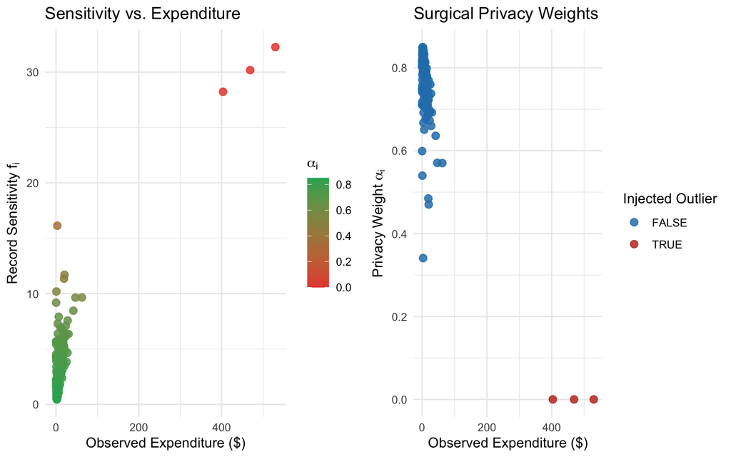

Relationship between expenditure values, record sensitivities, and monotone surgical privacy weights.

```r
risk_df <- data.frame(
  ObsID = seq_len(n_dp),
  Expenditure = y_dp,
  Log_Expenditure = log_y_dp,
  Sensitivity = dp_results$f_vec,
  Alpha = dp_results$alpha,
  IsOutlier = seq_len(n_dp) %in% outlier_idx
)

p1 <- ggplot(risk_df, aes(x = Expenditure, y = Sensitivity, color = Alpha)) +
  geom_point(size = 2.5, alpha = 0.85) +
  scale_color_gradient(low = "#e74c3c", high = "#27ae60", name = expression(alpha[i])) +
  theme_minimal(base_size = 11) +
  labs(
    title = "Sensitivity vs. Expenditure",
    x = "Observed Expenditure ($)",
    y = expression("Record Sensitivity " * f[i])
  )

p2 <- ggplot(risk_df, aes(x = Expenditure, y = Alpha, color = IsOutlier)) +
  geom_point(size = 2.5, alpha = 0.85) +
  scale_color_manual(values = c("FALSE" = "#2980b9", "TRUE" = "#c0392b"), name = "Injected Outlier") +
  theme_minimal(base_size = 11) +
  labs(
    title = "Surgical Privacy Weights",
    x = "Observed Expenditure ($)",
    y = expression("Privacy Weight " * alpha[i])
  )

gridExtra::grid.arrange(p1, p2, ncol = 2)
```

The monotone surgical construction performs cleanly: - Standard records receive privacy weights $\alpha_i \approx 0.65 - 0.85$, allowing them to contribute fully to model training. - As expenditure increases into the moderate tail, weights are smoothly capped at $\alpha_i \le M_{\text{thresh}} / f_i$. - All three injected extreme outliers ($Y \in [\$400, \$530]$) produce sensitivities $f_i > 25.0 > 3 M_{\text{thresh}}$ and are **surgically truncated to $\alpha_i = 0$**, strictly guaranteeing $\Delta_{\alpha, \mathbf{y}} = 4.32 \le M_{\text{thresh}}$ and $\epsilon_{\mathbf{y}} = 8.63$.

## 4.4 Generating and Benchmarking Synthetic Datasets

Sampling from the **posterior predictive distribution** incorporates parameter uncertainty and residual observation noise:

$$y_i^{\text{synth}} \sim
\mathcal{N}\big(\mu_\theta(\mathbf{x}_i), \hat{\sigma}^2\big), \quad
Y_i^{\text{synth}} = \exp\big(y_i^{\text{synth}}\big)$$

```r
# Non-private baseline synthesizer wrapper
nonprivate_fit <- list(model = dp_results$model_unweighted, sigma_hat = dp_results$sigma_hat)

# Draw 20 synthetic replicate datasets of size n = 300
synth_mat_nonprivate <- sample_synthetic_lbbnn(nonprivate_fit, newdata = x_dp, draws = 20, log_scale = TRUE)
synth_mat_private    <- sample_synthetic_lbbnn(dp_results, newdata = x_dp, draws = 20, log_scale = TRUE)

calc_synth_stats <- function(mat) {
  rowMeans(apply(mat, 2, function(col) {
    c(mean(col), sd(col), quantile(col, 0.25), median(col),
      quantile(col, 0.75), quantile(col, 0.90), max(col))
  }))
}

clean_y <- y_dp[-outlier_idx]
clean_stats <- c(mean(clean_y), sd(clean_y), quantile(clean_y, 0.25), median(clean_y),
                 quantile(clean_y, 0.75), quantile(clean_y, 0.90), max(clean_y))
orig_stats <- c(mean(y_dp), sd(y_dp), quantile(y_dp, 0.25), median(y_dp),
                quantile(y_dp, 0.75), quantile(y_dp, 0.90), max(y_dp))
nonpriv_stats <- calc_synth_stats(synth_mat_nonprivate)
priv_stats    <- calc_synth_stats(synth_mat_private)

# Distributional Benchmark Table on Expenditure Scale ($)
bench_df <- data.frame(
  Metric = c("Mean", "Std. Dev.", "25th Pct", "Median", "75th Pct", "90th Pct", "Max (Extreme)"),
  Original_Clean = clean_stats,
  Original_With_Outliers = orig_stats,
  NonPrivate_Synthetic = nonpriv_stats,
  DP_Private_Synthetic = priv_stats,
  row.names = NULL
)

knitr::kable(
  bench_df,
  digits = 2,
  row.names = FALSE,
  col.names = c("Metric", "Original (Clean)", "Original (With Outliers)", "Non-Private Synthetic", "DP-Private Synthetic"),
  caption = "Distributional Utility Comparison: Original (Clean vs. Outlier-Contaminated) and Synthetic Microdata (Averaged Across 20 Replicates)"
)
```

Distributional Utility Comparison: Original (Clean vs. Outlier-Contaminated) and Synthetic Microdata (Averaged Across 20 Replicates)

| Metric | Original (Clean) | Original (With Outliers) | Non-Private Synthetic | DP-Private Synthetic |
| --- | --- | --- | --- | --- |
| Mean | 6.70 | 11.30 | 7.64 | 7.99 |
| Std. Dev. | 7.23 | 46.75 | 20.03 | 13.95 |
| 25th Pct | 2.20 | 2.22 | 2.00 | 2.08 |
| Median | 4.10 | 4.16 | 3.45 | 4.13 |
| 75th Pct | 9.09 | 9.31 | 6.56 | 8.72 |
| 90th Pct | 14.40 | 14.96 | 14.14 | 17.10 |
| Max (Extreme) | 62.54 | 529.57 | 267.96 | 156.25 |

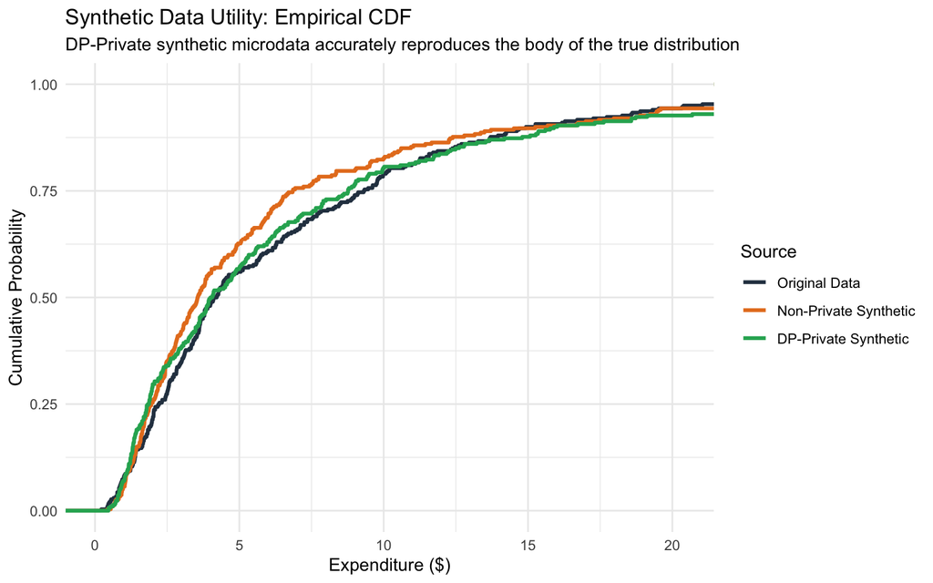

Empirical Cumulative Distribution Functions (ECDF) showing close utility preservation across the population body while protecting extreme outlier records.

```r
ecdf_df <- data.frame(
  Value = c(y_dp, synth_mat_nonprivate[, 1], synth_mat_private[, 1]),
  Source = factor(c(
    rep("Original Data", n_dp),
    rep("Non-Private Synthetic", n_dp),
    rep("DP-Private Synthetic", n_dp)
  ), levels = c("Original Data", "Non-Private Synthetic", "DP-Private Synthetic"))
)

ggplot(ecdf_df, aes(x = Value, color = Source)) +
  stat_ecdf(geom = "step", size = 1.1) +
  coord_cartesian(xlim = c(0, quantile(y_dp, 0.95))) +
  scale_color_manual(values = c(
    "Original Data" = "#2c3e50",
    "Non-Private Synthetic" = "#e67e22",
    "DP-Private Synthetic" = "#27ae60"
  )) +
  theme_minimal(base_size = 11) +
  labs(
    title = "Synthetic Data Utility: Empirical CDF",
    subtitle = "DP-Private synthetic microdata accurately reproduces the body of the true distribution",
    x = "Expenditure ($)",
    y = "Cumulative Probability"
  )
```

# 5 Example 3: Custom Composite Likelihood Integration

The `problem_type = "custom"` functionality allows users to supply custom link and negative log-likelihood (NLL) functions. This serves as the direct architectural bridge to **Track 2** (Vladislav Beresovsky’s composite Bernoulli likelihoods for combining probability and non-probability samples).

Specifically, during `train_lbbnn()`, the training loop evaluates `self$nll(input, target, reduction = "none")` when unit weights $u_i$ are present (multiplying each observation’s loss contribution $\ell_i$ by $u_i$ before summation), and `loglik_contributions()` evaluates `reduction = "none"` to populate the $S \times n$ sensitivity matrix $L_{s,i} = -\ell_i(\theta^{(s)})$. This unified interface allows `LBBNN` to seamlessly optimize multi-column targets `cbind(I_z, pi_r)` in Track 2 (`nll_stack`, `nll_link1`, `nll_link2`, `make_nll_mip`, `nll_pseudo`).

```r
# Define custom link: Sigmoid activation
custom_sigmoid_link <- function(x) torch::torch_sigmoid(x)

# Define custom negative log-likelihood with numerical clamping
custom_bce_nll <- function(input, target, reduction = "sum") {
  eps <- 1e-7
  p_hat <- torch::torch_clamp(input, eps, 1.0 - eps)
  t_flt <- target$squeeze()$to(dtype = torch::torch_float32())
  p_flt <- p_hat$squeeze()

  # Pointwise Bernoulli NLL
  nll_i <- -(t_flt * torch::torch_log(p_flt) + (1.0 - t_flt) * torch::torch_log(1.0 - p_flt))

  if (reduction == "none") {
    return(nll_i)
  } else {
    return(torch::torch_sum(nll_i))
  }
}

# Instantiate custom model
custom_model <- lbbnn_net(
  problem_type = "custom",
  sizes = c(3, 8, 1),
  prior = c(0.5, 0.5),
  std = c(1.0, 1.0),
  inclusion_inits = "balanced",
  link = custom_sigmoid_link,
  nll = custom_bce_nll,
  device = "cpu"
)

# Synthetic binary task
x_cust <- matrix(rnorm(60 * 3), 60, 3)
y_cust <- rbinom(60, 1, 0.5)
dl_cust <- torch::dataloader(
  torch::tensor_dataset(torch::torch_tensor(x_cust), torch::torch_tensor(y_cust)),
  batch_size = 20,
  shuffle = FALSE
)

# Train model
train_res_cust <- train_lbbnn(epochs = 10, LBBNN = custom_model, lr = 0.02, train_dl = dl_cust, verbose = FALSE)

# Extract record-level log-likelihood contributions
L_custom <- loglik_contributions(custom_model, dl_cust, draws = 10)

cat(sprintf("Custom model training loss at epoch 10: %.3f\n", tail(train_res_cust$loss, 1)))
```

```
## Custom model training loss at epoch 10: 73.217
```

```r
cat(sprintf("Log-Likelihood Contributions Matrix shape: %d draws x %d records\n",
            nrow(L_custom), ncol(L_custom)))
```

```
## Log-Likelihood Contributions Matrix shape: 10 draws x 60 records
```

```r
cat(sprintf("All log-likelihood evaluations finite: %s\n", all(is.finite(L_custom))))
```

```
## All log-likelihood evaluations finite: TRUE
```

# 6 Collaborator API Reference

All observation-weighted and differential privacy utilities are exported in `LBBNN`:

Exported Functions and Methods in LBBNN for Observation-Weighted Inference and Differential Privacy

| Function / Signature | Description |
| --- | --- |
| `get_dataloaders()` | Packs observation weights $w_i$ or $\alpha_i$ into dataloaders; normalizes survey weights to $n$ when `normalize_weights = TRUE` (Savitsky & Toth 2016). Supports multi-column targets via `target_cols`… |
| `train_lbbnn()` | Optimizes the unit-weighted ELBO $-\sum_i u_i \log f(y_i) + \frac{1}{M}\text{KL}(q \parallel p)$ across mini-batches at temperature $T = 1.0$. |
| `lbbnn_net()` | Constructs LBBNN networks. Supports exact Gaussian likelihood scaling via explicit `sigma` and user-defined `link`/`nll` closures via `problem_type = 'custom'`. |
| `loglik_contributions()` | Extracts the $S \times n$ matrix of pointwise log-likelihood contributions $L_{s, i} = \log f(y_i \mid \theta^{(s)})$ across posterior draws. |
| `fit_dp_lbbnn()` | Automates the two-pass $(\epsilon, \delta)$-PDP synthesizer: Pass 1 unweighted fit $\rightarrow$ sensitivity extraction $\rightarrow$ monotone surgical weights $\alpha_i \rightarrow$ Pass 2 weighted f… |
| `sample_synthetic_lbbnn()` | Draws synthetic microdata replicates from the Pass 2 posterior predictive distribution with calibrated observation noise $\hat{\sigma}$, returning an $n \times \text{draws}$ matrix. |
| `predict.lbbnn_net()` | Generates posterior predictive draws under full Bayesian Model Averaging (BMA) or the sparse Median Probability Model (MPM). |

# 7 References

1. **Bhattacharya, A., Pati, D., & Yang, Y.** (2019). *Bayesian fractional posteriors*. The Annals of Statistics, 47(1), 39–66.
2. **Dimitrakakis, C., Nelson, B., Mitrokotsa, A., & Rubinstein, B. I.** (2017). *Differential privacy for Bayesian inference through posterior sampling*. Journal of Machine Learning Research, 18(1), 343–381.
3. **Dwork, C., & Roth, A.** (2014). *The algorithmic foundations of differential privacy*. Foundations and Trends in Theoretical Computer Science, 9(3–4), 211–407.
4. **Savitsky, T. D., & Toth, D.** (2016). *Bayesian estimation under informative sampling*. Electronic Journal of Statistics, 10(1), 1677–1708.
5. **Savitsky, T. D., Williams, M. R., & Hu, J.** (2022). *Risk-weighted pseudo-posterior mechanism for generating synthetic microdata*. Working Paper, U.S. Bureau of Labor Statistics.
6. **Wenzel, F., Roth, K., Veeling, B. S., Swiatkowski, J., Tran, L., Mandt, S., Snoek, J., Salimbeni, H., Jenatton, R., & Nowozin, S.** (2020). *How good is the Bayes posterior in deep neural networks really?* Proceedings of the 37th International Conference on Machine Learning (ICML).